# Health Service Coverage Report

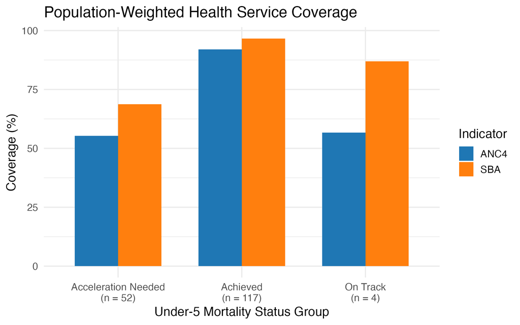

### Interpretation

This analysis combines three publicly available data sources to examine maternal health service coverage in relation to progress toward under-five mortality (U5MR) targets. We calculate population-weighted averages for two indicators—antenatal care (ANC4) and skilled birth attendance (SBA)—using 2022 birth estimates from the UN World Population Prospects. Countries are grouped based on their U5MR classification: **Achieved**, **On Track**, or **Acceleration Needed**, per UNICEF’s tracking framework.

As shown in the figure, **countries that have achieved** the U5MR target demonstrate the highest population-weighted coverage: **over 90% for both ANC4 and SBA**. **Countries on track** show **mixed performance**, with high SBA coverage (~87%) but considerably lower ANC4 coverage (~57%). In contrast, **off-track countries** (acceleration needed) display the **lowest coverage**, averaging ~55% for ANC4 and ~69% for SBA.

These descriptive results underscore disparities in maternal health service access that correspond with progress toward child mortality goals. However, these patterns are not causal; they may reflect broader structural factors such as health system capacity, governance, or conflict.

Note: The “On Track” group includes only 4 countries. While the SBA coverage is relatively high (~87%), the small group size may limit generalizability. Interpret these results with caution.

**Examples** of countries in each group:

- **Achieved**: Australia, Paraguay, Malaysia
- **On Track**: Egypt, Mongolia, Algeria
- **Acceleration Needed**: Mauritania, Zimbabwe, Chad

Table 1. Population-Weighted Coverage by U5MR Status Group

| U5MR Status | ANC4 Coverage | SBA Coverage | Countries with Data | Total Countries | Coverage % |
| --- | --- | --- | --- | --- | --- |
| Acceleration Needed | 55.30 | 68.73 | 52 | 52 | 100% |
| Achieved | 92.02 | 96.64 | 117 | 117 | 100% |
| On Track | 56.67 | 86.99 | 4 | 4 | 100% |